# Predicting Credit Risk

# 6 Meta-algorithmes - prédiction

```r
#l'objet don correspond au jeu de données German Credit
set.seed(235)
id<-sample(seq(nrow(don)),size=ceiling(nrow(don)*2/3))
test<-don[-id,]
ech<-don[id,]
```

Maintenant on va choisir quel algorithme est le plus précis pour prédire la variable réponse **Creditability** dont les modalités sont “good” et “bad”. Creditability indique que la décison d’accorder ou non un crédit bancaire. On va utiliser 5 algorithmes et comparer les performances de ces modèles.

**1.Decision Trees CART Bagging**

**2.Logistic Regression binaire**

**3.Random Forests**

**4.Naives Bayes**

**5.Neural Networks**

## 6.1 Bagging

```r
start_timeglm1= Sys.time()
set.seed(235)
library(ROCR)
library(rpart)#classifer Tree
res.tree<-rpart(Creditability~.,data=ech)#ajustement de l'arbre non élagué
res.prune<-prune(res.tree,cp=0.046)#élagage
res.pred<-predict(res.prune,newdata = test)[,1]#calcul des probabilités d'être bon payeur sur l'échantillon test
AUC_CART<-performance(prediction(res.pred,test$Creditability),measure="auc")@y.values[[1]]#calcul de l'AUC
Err_CART<-performance(prediction(res.pred,test$Creditability),measure ="err")@y.values[[1]][4]#calcul de l'erreur de mauvais classement
cat("AUC CART : ", AUC_CART);
```

```
## AUC CART :  0.7146249
```

```r
cat(" Erreur CART : ",Err_CART)#affichage
```

```
##  Erreur CART :  0.2762763
```

```r
end_timeglm1= Sys.time()
end_timeglm1 - start_timeglm1
```

```
## Time difference of 0.2095792 secs
```

[figure not shown]

```r
fancyRpartPlot(res.tree,palettes=c("Blues", "Oranges"),cex=0.4,main="Decision Tree", tweak=1)
```

```r
set.seed(235)
library(ipred)
start_timebag= Sys.time()
bag<-bagging(Creditability~.,
             data=ech,
             nbagg=200,
             coob=TRUE,
             control=rpart.control(minbucket = 5))

end_timebag= Sys.time()
end_timebag - start_timebag
```

```
## Time difference of 9.533347 secs
```

```r
#agregation des proba
test$bag1<-predict(bag,test,type="prob",aggregation="average")
pred1<-prediction(test$bag1[,1],test$Creditability)
AUC_proba<-performance(pred1,"auc")@y.values[[1]]

#agregation des valeurs prédites
test$bag2<-predict(bag,test,type="prob",aggregation="majority")
pred2<-prediction(test$bag2[,1],test$Creditability)

AUC_pred<-performance(pred2,"auc")@y.values[[1]]

cat("AUC selon probabilités : ", AUC_proba);
```

```
## AUC selon probabilités :  0.787922
```

```r
cat("AUC selon prédictions : ", AUC_pred)
```

```
## AUC selon prédictions :  0.7883105
```

```r
#accuracy
#confusionglm<-table(test$bag2, test$Creditability)
#bag2.acc <-(confusionglm[1,1] + confusionglm[2,2])/sum(confusionglm)
#bag2.recall<-confusionglm[1,1]/(confusionglm[1,1]+confusionglm[2,1])
#bag2.precision<- confusionglm[1,1]/(confusionglm[1,1]+confusionglm[1,2])
#bag2.fscore<- (2*confusionglm[1,1])/((2*confusionglm[1,1])+confusionglm[1,2]+confusionglm[2,1])

resultats.bag2<- data.frame( 'Durée'=c(end_timebag - start_timebag),Accuracy=c(AUC_pred),'Taux Erreur' = c(1-AUC_pred), Recall=c("-"), Precision=c("-"),F1score=c("-") ,row.names=c("Bagging CART"))
library(kableExtra)#tableau


#resultat
kableExtra::kable(resultats.bag2,booktabs= T,caption = "Resultats Bagging CART")  %>%
  kable_styling(bootstrap_options = c("striped", "hover", "condensed", "responsive"))
```

Resultats Bagging CART

Durée

Accuracy

Taux.Erreur

Recall

Precision

F1score

Bagging CART

0.7883105

0.2116895

Enfin, on peut vérifier que l’erreur OOB est proche du taux de mauvais classement obtenu sur l’échantillon test.

```r
cat("erreur test : ",performance(pred1,measure ="err")@y.values[[1]][251]);
```

```
## erreur test :  0.2312312
```

```r
cat("erreur OOB : ",bag$err)
```

```
## erreur OOB :  0.2488756
```

## 6.2 Forêts aléatoires

```r
library(randomForest)
set.seed(235)
res.rf<-randomForest(ech$Creditability,x=ech[,-c(21,22)],ntree = 200)
#cat("AUC Random_Forest : ", performance(prediction(predict(res.rf,test,type="prob",aggregation="average")[,1],test$Creditability),"auc")@y.values[[1]])
```

Voici le resultat de l’apprentissage :

```r
#modele
res.rf$confusion
```

```
##      good bad class.error
## good  466   0           0
## bad     0 201           0
```

#### Apply model to the test set

```r
predict_rf<-predict(res.rf, test)
```

Nous calculons la confusion Matrice de confusion.

```r
#confusion
#postResample(predict_rf, test$Creditability)

caret::confusionMatrix(predict_rf, test$Creditability)
```

```
## Confusion Matrix and Statistics
##
##           Reference
## Prediction good bad
##       good  234   0
##       bad     0  99
##
##                Accuracy : 1
##                  95% CI : (0.989, 1)
##     No Information Rate : 0.7027
##     P-Value [Acc > NIR] : < 2.2e-16
##
##                   Kappa : 1
##
##  Mcnemar's Test P-Value : NA
##
##             Sensitivity : 1.0000
##             Specificity : 1.0000
##          Pos Pred Value : 1.0000
##          Neg Pred Value : 1.0000
##              Prevalence : 0.7027
##          Detection Rate : 0.7027
##    Detection Prevalence : 0.7027
##       Balanced Accuracy : 1.0000
##
##        'Positive' Class : good
##
```

Pas d’erreur.

## Boosting

A présent, on propose de comparer le bagging au boosting en utilisant comme prédicteur de base des stumps qui ont l’avantage d’être peu coûteux algorithmiquement. Le boosting peut être par exemple réalisé à l’aide du package R gbm ou ada. On commence par inspecter l’influence du nombre d’itérations de la procédure sur l’erreur en considérant l’échantillon d’apprentissage ou l’échantillon test.

```r
library(gbm)
```

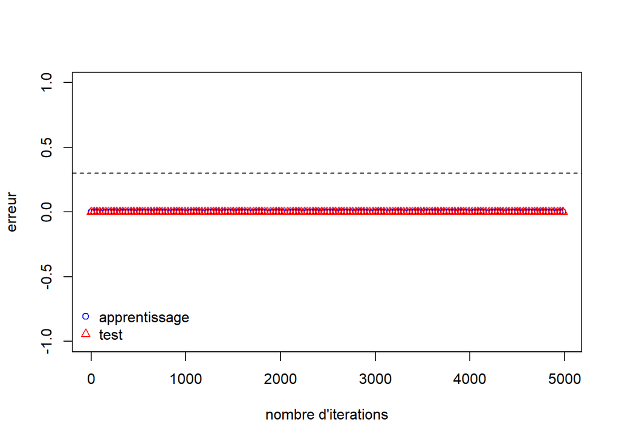

```r
set.seed(235)
B<-5000#nombre d'iterations
ech$Creditability.bin<-as.numeric(ech$Creditability)-1#0 = good
test$Creditability.bin<-as.numeric(test$Creditability)-1
model <- gbm(Creditability.bin~.,data=ech[,-21],distribution="adaboost",interaction.depth=1,shrinkage=1,n.trees=B)

#représentation graphique de l'influence de B
boucle <- seq(1,B,by=30)
errapp <- errtest <-rep(0,length(boucle))

k <- 0
for (i in boucle){
 k <- k+1
 prev_app <- predict(model,newdata=ech[,-21],n.trees=i)
 errapp[k] <- sum(as.numeric(prev_app>0)!=ech[,-21]$Creditability.bin)/nrow(ech)
 prev_test<- predict(model,newdata=test[,-21],n.trees=i)
 errtest[k] <- sum(as.numeric(prev_test>0)!=test[,-21]$Creditability.bin)/nrow(test)
}

plot(boucle,errapp,type="b",col="blue",xlab="nombre d'iterations",
ylab="erreur",lty=1) #ylim=c(0,0.03)
points(boucle,errtest,col="red",type="b",pch=2)
abline(0.3,0,lty=2)
legend("bottomleft",legend=c("apprentissage","test"),col=c("blue","red"),pch=c(1,2),bty="n")
```

```r
AUC_boosting<-gbm.roc.area(test$Creditability.bin, predict(model,newdata=test[,-21],n.trees = 120))
cat("AUC boosting : ",AUC_boosting)
```

```
## AUC boosting :  1
```

Comparons à présent avec la procédure de bagging sur les stumps

```r
set.seed(235)
stump<-bagging(Creditability~.,data=don[id,],nbagg=200,coob=TRUE,control=rpart.control(maxdepth = 1,cp=-1))
test$stump<-predict(stump,test,type="prob",aggregation="average")
pred<-prediction(test$stump[,1],test$Creditability)
AUC_bagging<-performance(pred,"auc")@y.values[[1]]
cat("AUC bagging : ",AUC_bagging)
```

```
## AUC bagging :  0.6981568
```

L’AUC est plus faible. Ceci n’est pas surprenant car le boosting permet de corriger à la fois le biais et la variance des stumps, tandis que le bagging ne diminue que la variance.

Pour rappel:

La précision compte la proportion d’items pertinents parmi les items sélectionnés

Le rappel compte la proportion d’items pertinents sélectionnés parmi tous les items pertinents sélectionnables